# Lab-1:2: Theming with matplotlib

**Instructions**

This notebook consists of TWO parts

(1): **Demonstration section:** The instructors will work through this section during the lab period. It is meant to be educational, with various code examples provided for you. You should understand all code in the demonstration section and should run the cells on your local machine before attempting the assignment.

(2): **Lab assignment:** A short assignment section is also provided after the demonstration. You will have time to work on this during the lab but can finish it at home.

**NOTE**: It is recommended that you complete this `.ipynb` file in VS-code. Activate the `anly503` environment by selecting the kernel in the upper-left corner of VS-code.

**Submission:**

- You need to upload TWO documents to Canvas when you are done
  - (1) A PDF (or HTML) of the completed form of this notebook
  - (2) The `lab-1.2.mplstyle` theming file which you create in the assignment section
  - Failure to submit BOTH versions will result in a 10% deduction per missing document.
- The final uploaded version should NOT have any code-errors present
- All outputs must be visible in the uploaded version, including code-cell outputs, images, graphs, etc

# Import packages

The following are the packages used in this lab

```python
import pandas as pd
import matplotlib.pyplot as plt
import matplotlib as mpl
import seaborn as sns
import numpy as np
```

# Demonstration section

Make sure you understand all code in the demonstration section.

Also run the cells on your local machine before attempting the assignment.

## MPL fundamental (review)

- Most python visualization libraries are built on top of matplotlib (e.g. Seaborn, networkx.draw(), etc).
- Therefore, you really should attempt to master matplotlib as much as possible.
- This "MPL fundamental" section content was covered in boot-camp, however, it is included for completeness and you should review it if you are un-familiar with it.
- We will run through it quickly, to refresh your memory.

## Pyplot

- matplotlib.pyplot is a collection of functions that make matplotlib work like MATLAB.
- Each pyplot function makes some change to a figure: e.g.,
  - creates a figure, creates a plotting area in a figure, plots some lines in a plotting area, decorates the plot with labels, etc.
- In matplotlib.pyplot states are preserved across function calls.
  - This means it keeps track of things like the current figure and plotting area
  - The plotting functions are directed to the current axes

## Figures and axes

In matplotlib there are two important object types, the figure object and the axes object.

- This sometimes leads to confusion, because you will see code that uses axes objects commands and sometimes not.
- So what is the difference between these two objects?
- **Figures** (think of this as your "canvas")
  - Think of figures as the blank canvas (or paper) on which you are going to put your plots (i.e. the whole figure).
  - The Figure keeps track of all the child Axes, a group of attributes (titles, figure legends, colorbars, etc), and even nested subfigures.
  - It is often convenient to create the Axes together with the Figure, but you can also manually add Axes later on.
  - When you modify the figure attribute you are modifying the canvas rather than the subplots
- **Axes** (individual plots)
  - Think of axes as the individual plots that go on the paper.
    - Each figure (canvas) can contain one or more Axes.
      - Just like with pen and paper, you can put one plot on the paper or many (i.e. subplots)
    - The axes are areas where points can be specified in terms of x-y coordinate system
      - (or theta-r in a polar plot, x-y-z in a 3D plot, etc).
    - The simplest way of creating a Figure with an Axes is using pyplot.subplots.
    - We can then use Axes.plot to draw some data on the Axes:
    - The Axes class and its member functions are the primary entry point to working with the MLP interface
      - They have most of the plotting methods defined on them (e.g. ax.plot())

The following figure exemplifies the difference between the two types of objects.

[figure not shown]

Notice that we can have multiple axes objects per figure.

[figure not shown]

**Because of these two object types, there are essentially two ways to use Matplotlib:**

- Method-1) Rely on pyplot to automatically create and manage the Figures and Axes, and use pyplot functions for plotting.
- Method-2) Explicitly create Figures and Axes, and call methods on them (i.e. the "object-oriented (OO) style").

### Method-1

- In this case we don't explicitly define the figure and axes object
- However, the code implicitly defines them in the background

```python
import matplotlib.pyplot as plt
import numpy as np

#DEFINE DATA
x=[1, 2, 3, 4]
y=[1, 2, 3, 4]

#PLOT
plt.plot(x,y,'o') # 'o' makes a scatterplot or point plot
plt.show()
```

```python
import matplotlib.pyplot as plt
import numpy as np

#DEFINE DATA
x=[1, 2, 3, 4]
y=[1, 2, 3, 4]

#PLOT
plt.plot(x,y,'o') # 'o' makes a scatterplot or point plot
plt.show()
```

**Basic customization**

- We can still do some basic customization, even though we did not explicitly define the figure and axes objects.
- These commands are modifying attributes of the implicitly defined figure object.

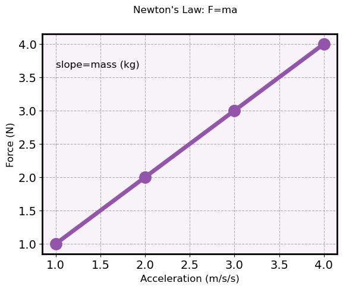

```python
import matplotlib.pyplot as plt

#DEFINE DATA
x=[1, 2, 3, 4]
y=[1, 2, 3, 4]

#PLOT
plt.plot(x,y,'-o') # '-o' makes plots points and a line

#SET FIGURE LABELS AND TITLE
FS=12
plt.suptitle("Newton's Law: F=ma", fontsize=FS)
plt.xlabel('Acceleration (m/s/s)', fontsize=FS)
plt.ylabel('Force (N)', fontsize=FS)
#TUPLE SPECIFIES WHERE TO PUT ANNOTATION
plt.annotate("slope=mass (kg)", (1,3.65), fontsize=FS)
plt.show()
```

### Method-2

- In this case we explicitly define both a figure object and an axes object.
- This method is preferred, because it is more explicit, and it generalizes to the case of subplots, as we will see later.

```python
import matplotlib.pyplot as plt
import numpy as np

#DEFINE DATA
x=[1, 2, 3, 4]
y=[1, 2, 3, 4]

#DEFINE OBJECTS
fig, ax = plt.subplots()

#PLOT
ax.plot(x,y,'o')
plt.show()
```

**Basic customization**

- Just as with method-1, we can do various forms of customization.
- However notice that some of the commands are different, since we are acting on the axis object.

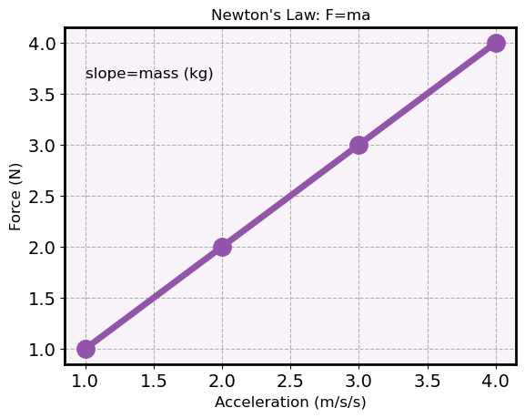

```python
import matplotlib.pyplot as plt
import numpy as np

#DEFINE DATA
x=[1, 2, 3, 4]
y=[1, 2, 3, 4]

#DEFINE OBJECTS
fig, ax = plt.subplots()

#PLOT
ax.plot(x,y,'-o')

#CUSTOMIZE
FS=12
ax.set_title("Newton's Law: F=ma", fontsize=FS)
ax.set_xlabel('Acceleration (m/s/s)', fontsize=FS)
ax.set_ylabel('Force (N)', fontsize=FS)
ax.annotate("slope=mass (kg)", (1,3.65), fontsize=FS)
plt.show()
```

## Seaborn fundamental (review)

This section content was also covered in boot-camp, however, it is included for completeness and you should review it if you are un-familiar with it.

We will run through it quickly, to refresh your memory.

### Overview

Seaborn is a library for making statistical graphics in Python.

It builds on top of matplotlib and integrates closely with pandas data structures.

It provides a high-level interface for drawing attractive and informative statistical graphics.

Its plotting functions operate on dataframes and arrays containing whole datasets and internally perform the necessary semantic mapping and statistical aggregation to produce informative plots.

Its dataset-oriented, declarative API lets you focus on what the different elements of your plots mean, rather than on the details of how to draw them.

For more see: https://seaborn.pydata.org/

### Matplotlib inheritance

Seaborn is built on top of Matplotlib. Therefore, depending on the plotting command, it will return either a Matplotlib axes or figure object.

You can determine what is returned using the Python type() function

```python
# LOAD THE DATA-FRAME (REQUIRES INTERNET)
df = sns.load_dataset("tips")
print(df)
```

```
     total_bill   tip     sex smoker   day    time  size
0         16.99  1.01  Female     No   Sun  Dinner     2
1         10.34  1.66    Male     No   Sun  Dinner     3
2         21.01  3.50    Male     No   Sun  Dinner     3
3         23.68  3.31    Male     No   Sun  Dinner     2
4         24.59  3.61  Female     No   Sun  Dinner     4
..          ...   ...     ...    ...   ...     ...   ...
239       29.03  5.92    Male     No   Sat  Dinner     3
240       27.18  2.00  Female    Yes   Sat  Dinner     2
241       22.67  2.00    Male    Yes   Sat  Dinner     2
242       17.82  1.75    Male     No   Sat  Dinner     2
243       18.78  3.00  Female     No  Thur  Dinner     2

[244 rows x 7 columns]
```

```python
sns_plt=sns.scatterplot(data=df, x="total_bill", y="tip")
# Notice, that the sns.scatterplot() function returns a MPL axes object. Therefore, we can use various MatplotLib axes commands to modify the Seaborn figure.
print(type(sns_plt))
```

```
<class 'matplotlib.axes._subplots.AxesSubplot'>
```

### Seaborn color palettes

The following link has all MPL color-maps

https://matplotlib.org/stable/tutorials/colors/colormaps.html

sns built-in styles can be found here

https://seaborn.pydata.org/generated/seaborn.set_style.html

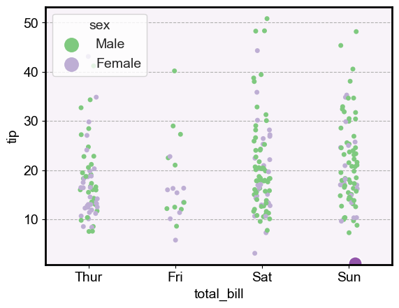

```python
sns.set_palette('Accent')
sns.set_style("whitegrid")
sns.stripplot(x='day', y='total_bill', hue="sex",data=df)
plt.show()
```

```python
# RESET BACK TO DEFAULTS
plt.rcParams.update(plt.rcParamsDefault)
```

## FacetGrid objects

In some cases, Seaborn will return a "FacetGrid" object which is not a MLP axes or figure object.

```
<class 'seaborn.axisgrid.FacetGrid'>
```

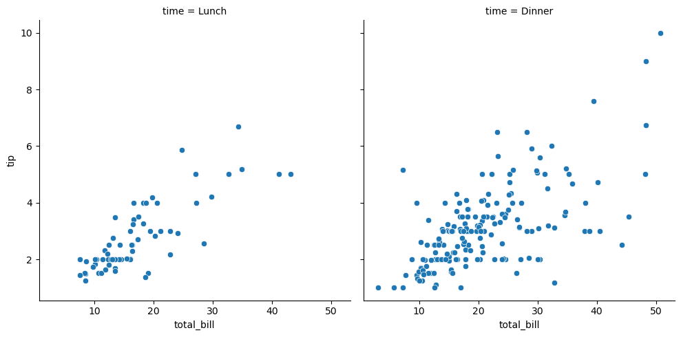

```python
my_plot=sns.relplot(
data=df,
x="total_bill",
y="tip",
col="time"
)
#NOTICE THE TYPES IS <class 'seaborn.axisgrid.FacetGrid'> NOT A MPL OBJECT
print(type(my_plot))
plt.show()
```

## Customizing FacetGrid objects

However, you can typically access the underline MLP objects via the attributes of the returned object, as shown in the following example.

This allows you to customize a Seaborn plot just like you would a regular MPL plot.

```
-----TYPES-----
<class 'matplotlib.figure.Figure'>
<class 'matplotlib.axes._subplots.AxesSubplot'>
<class 'matplotlib.axes._subplots.AxesSubplot'>
```

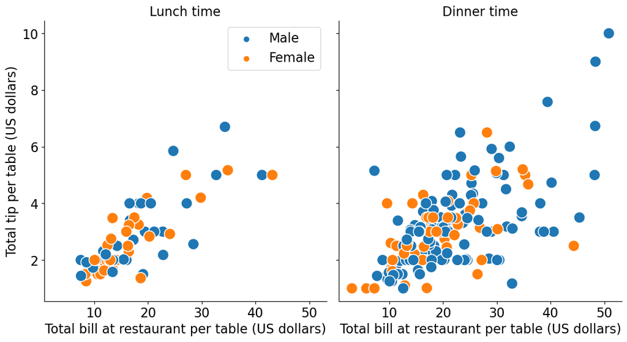

```python
g=sns.relplot(
data=df,
x="total_bill",
y="tip",
hue="sex",
col="time",
s=200,
)

#NOTICE THAT <class 'seaborn.axisgrid.FacetGrid'> OBJECT HAS ATTRIBUTES CONTAINING MPL OBJECTS
print('-----TYPES-----')
print(type(g.fig))
print(type(g.axes[0,0]))
print(type(g.axes[0,1]))

# BY ACCESSING THE MPL AXES/FIG ATTRIBUTES, WE CAN USE ALL OF OUR FAMILIAR MPL COMMANDS TO CUSTOMIZE

FS=16

#FIGURE TITLE
g.fig.set_size_inches(12, 6)

#AXIS LABELS AND FONT SIZE
g.axes[0,0].set_xlabel('Total bill at restaurant per table (US dollars)', fontsize=FS)
g.axes[0,0].set_ylabel('Total tip per table (US dollars)', fontsize=FS)
g.axes[0,1].set_xlabel('Total bill at restaurant per table (US dollars)', fontsize=FS)

#TITLE FONT SIZE
g.axes[0,0].set_title("Lunch time",fontsize=FS)
g.axes[0,1].set_title("Dinner time",fontsize=FS)


#AXIS TIC FONT SIZE
for i in range(0,2):
    g.axes[0,i].tick_params(axis='both', which='major', labelsize=FS)
    #g.axes[0,i].tick_params(axis='both', which='minor', labelsize=FS)

#LEGEND FONT SIZE
g.axes[0,0].legend(fontsize=FS)

#REMOVE SIDE LEGEND
g._legend.remove()

plt.show()
```

# Theme creation

Typically the default properties of plots are un-acceptable for professional level presentations.

This is because, the labels are not very intuitive, lack units, and have font that is too small.

Therefore, we often want to modify them to generate higher-quality visualizations.

**The default parameters of MPL are stored in an object called rcParams which is similar to a dictionary**

**Therefore, there are essentially four ways to customize Matplotlib:**

- 1) Modifying rcParams at runtime.
- 2) Using style sheets.
- 3) Changing your matplotlibrc file.
- 4) Manually modifying attributes of your plot when you create it (as shown in the simple example above)

**NOTE**: Setting rcParams at runtime takes precedence over style sheets, style sheets take precedence over matplotlibrc files.

**NOTE:**: If you change the parameters in rcParams they will be re-set when you restart the python kernel.

You can print the defaults in the rcParams object, as shown below.

## rcParams file

`matplotlib` has a styling system that is a bit more robust, using a construct called `rcParams`

When you use a style in `matplotlib`, what happens under the hood is that various elements of `matplotlib.rcParams` are changed to meet the specifications.

You can manipulate `matplotlib.rcParams` yourself as well.

```python
# THIS IS IMPORTANT: THERE ARE 308 ENTRIES IN rcParam
# WHICH SHOWS YOU MOST OF WHAT YOU CAN CUSTOMIZE WITH MPL
print(plt.rcParams)
```

```
_internal.classic_mode: False
agg.path.chunksize: 0
animation.bitrate: -1
animation.codec: h264
animation.convert_args: ['-layers', 'OptimizePlus']
animation.convert_path: convert
animation.embed_limit: 20.0
animation.ffmpeg_args: []
animation.ffmpeg_path: ffmpeg
animation.frame_format: png
animation.html: none
animation.writer: ffmpeg
axes.autolimit_mode: data
axes.axisbelow: line
axes.edgecolor: black
axes.facecolor: white
axes.formatter.limits: [-5, 6]
axes.formatter.min_exponent: 0
axes.formatter.offset_threshold: 4
axes.formatter.use_locale: False
axes.formatter.use_mathtext: False
axes.formatter.useoffset: True
axes.grid: False
axes.grid.axis: both
axes.grid.which: major
axes.labelcolor: black
axes.labelpad: 4.0
axes.labelsize: medium
axes.labelweight: normal
axes.linewidth: 0.8
axes.prop_cycle: cycler('color', ['#1f77b4', '#ff7f0e', '#2ca02c', '#d62728', '#9467bd', '#8c564b', '#e377c2', '#7f7f7f', '#bcbd22', '#17becf'])
axes.spines.bottom: True
axes.spines.left: True
axes.spines.right: True
axes.spines.top: True
axes.titlecolor: auto
axes.titlelocation: center
axes.titlepad: 6.0
axes.titlesize: large
axes.titleweight: normal
```

[output cut: 253 more lines]

```
ytick.labelright: False
ytick.labelsize: medium
ytick.left: True
ytick.major.left: True
ytick.major.pad: 3.5
ytick.major.right: True
ytick.major.size: 3.5
ytick.major.width: 0.8
ytick.minor.left: True
ytick.minor.pad: 3.4
ytick.minor.right: True
ytick.minor.size: 2.0
ytick.minor.visible: False
ytick.minor.width: 0.6
ytick.right: False
```

### Plot with default rcParam

lets start with a default mpl plot

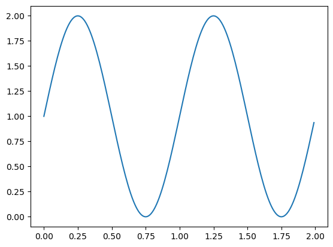

```python
def mpl_plot():
    # DATA FOR PLOTTING
    t = np.arange(0.0, 2.0, 0.01)
    s = 1 + np.sin(2 * np.pi * t)

    # INITIALIZE
    fig, ax = plt.subplots()

    # PLOT
    ax.plot(t, s)
    plt.show()

mpl_plot()
```

```python
# LETS START WITH A GENERIC DEFAULT SEABORN PLOT

def sns_plot():
    tips = sns.load_dataset("tips")  # USE DEFAULT DATA-SET INCLUDED WITH PYTHON
    sns.histplot(tips['total_bill'])
    plt.show()

sns_plot()
```

### Editing rcParam

This modification will effect all future plots, unless we change it back.

Or until we restart the python kernel, e.g. by reopening the .ipynb file or re-running the .py file

This will restore the un-modified rcParam defaults.

```python
# print(type(plt.rcParams))
print("BEFORE:", plt.rcParams["figure.figsize"])

# YOU CAN ALSO MODIFY THESE ATTRIBUTES
plt.rcParams["figure.figsize"]= (10,10)     # change the default figure size to a 10in x 10in resolution
print("AFTER:",plt.rcParams["figure.figsize"])

plt.rcParams["axes.grid"]=True
plt.rcParams["axes.linewidth"]=2
plt.rcParams["lines.linewidth"]= 4
plt.rcParams["lines.linestyle"]="dotted"
# change the order in which colors are chosen
plt.rcParams['axes.prop_cycle'] = plt.cycler(color=['#32a852', 'r', 'b', 'y'])
plt.rcParams['font.size']=16
plt.rcParams['axes.facecolor']= 'f0f0f0'
plt.rcParams['font.family'] = 'serif'
plt.rcParams['lines.linewidth']= 5
plt.rcParams['xtick.labelsize'] = 24
plt.rcParams['ytick.labelsize'] = 24
```

```
BEFORE: [6.4, 4.8]
AFTER: [10.0, 10.0]
```

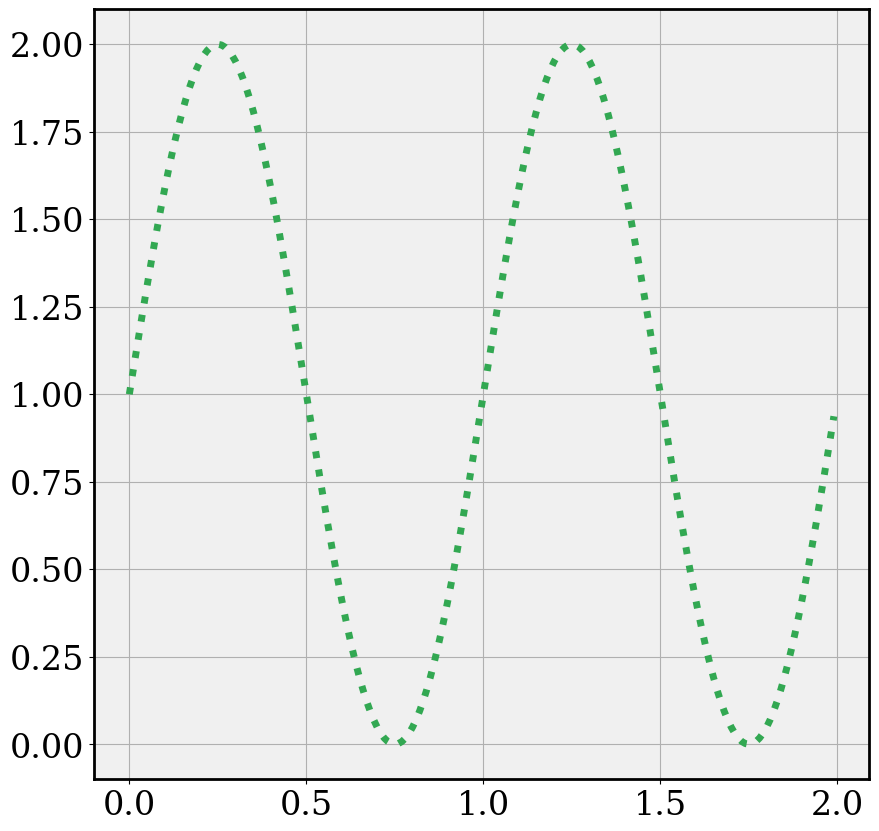

```python
## Notice the changes to our simple plots from above
mpl_plot()
```

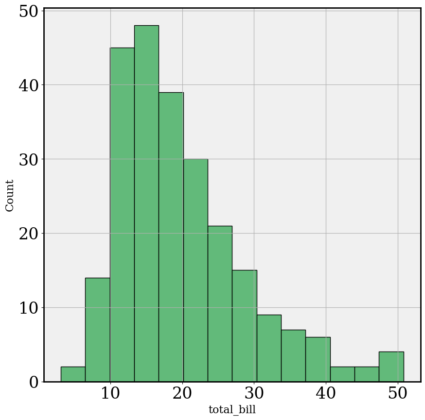

```python
# NOTICE THE CHANGES OCCUR IN SEABORN TOO, SINCE IT ALSO USES rcParam
sns_plot()
```

```python
# RESET BACK TO DEFAULTS
plt.rcParams.update(plt.rcParamsDefault)
```

## Matplotlib themes

There are several themes available in Python for generating the look and feel of your visualizations.

However, especially for your project, we want you to develop your own custom theme.

```python
# LIST AVAILABLE THEMES
import matplotlib.pyplot as plt
sorted(plt.style.available)
```

```
['Solarize_Light2',
 '_classic_test_patch',
 '_mpl-gallery',
 '_mpl-gallery-nogrid',
 'bmh',
 'classic',
 'dark_background',
 'fast',
 'fivethirtyeight',
 'ggplot',
 'grayscale',
 'mycustomstyle',
 'seaborn-v0_8',
 'seaborn-v0_8-bright',
 'seaborn-v0_8-colorblind',
 'seaborn-v0_8-dark',
 'seaborn-v0_8-dark-palette',
 'seaborn-v0_8-darkgrid',
 'seaborn-v0_8-deep',
 'seaborn-v0_8-muted',
 'seaborn-v0_8-notebook',
 'seaborn-v0_8-paper',
 'seaborn-v0_8-pastel',
 'seaborn-v0_8-poster',
 'seaborn-v0_8-talk',
 'seaborn-v0_8-ticks',
 'seaborn-v0_8-white',
 'seaborn-v0_8-whitegrid',
 'tableau-colorblind10']
```

To specify a style to use, you can use `mpl.style.use`

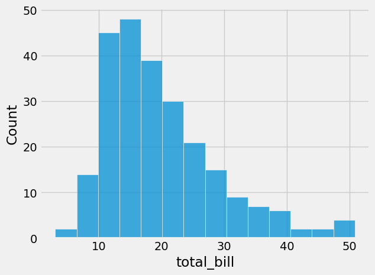

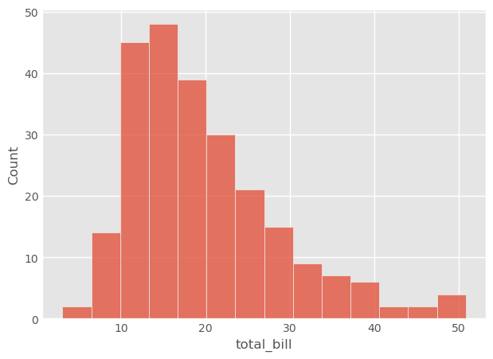

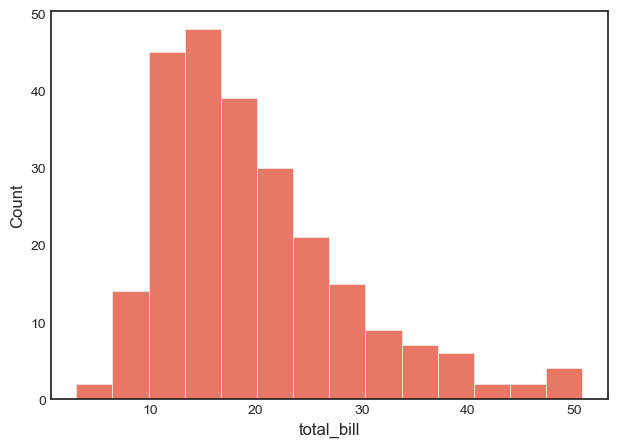

```python
plt.style.use("fivethirtyeight")
sns_plot()

plt.style.use("ggplot")
sns_plot()

plt.style.use("seaborn-v0_8-white")
sns_plot()

plt.style.use("default") #revert to default
sns_plot()
```

```python
# RESET BACK TO DEFAULTS
plt.rcParams.update(plt.rcParamsDefault)
```

## The `matplotlibrc` file

You can save your configuration (going into `rcParams`) in a file named `matplotlibrc`.

You can have a global one, stored in `mpl.get_configdir()`

You can also have separate ones per project or folder.

**Advantage**: You can put the configuration under version control and maintain its provenance.

The `matplotlibrc` file would look something like this, similar to a python dictionary

```
axes.axisbelow : True       # Draw axis grid lines and ticks below patches (True); above
                            # patches but below lines ('line'); or above all (False).
                            # Forces grid lines below figures.
font.size : 12              # Font size in pt.
grid.linewidth : 1.2        # In pt.
legend.framealpha : 1       # Legend patch transparency.
legend.scatterpoints : 3    # Number of scatter points in legend.
lines.linewidth : 3         # line width in pt.
```

Notice that the tags are the same as in rcParams, so you can edit the file in a similar way.

## Create a new *style*

```python
from pathlib import Path
cfgdir = mpl.get_configdir() # find your configuration folder
p = Path(cfgdir)
print(p)
stylelib = (p / 'stylelib')
stylelib.mkdir(exist_ok=True)
path = stylelib / 'mycustomstyle.mplstyle' # create paths
path.write_text(''' # write into the file
axes.facecolor : f0f0f0
font.family : serif
lines.linewidth : 5
xtick.labelsize : 24
ytick.labelsize : 24
''')
```

```
C:\Users\Eric\.matplotlib
```

```
129
```

This creates a new file `mycustomstyle.mplstyle`.

Reload the matplotlib style library and you'll see this style appear as `mycustomstyle`

```python
# BEFORE
sns_plot()
```

```python
# LOAD STYLE
plt.style.reload_library()
print('mycustomstyle' in plt.style.available)
```

```
True
```

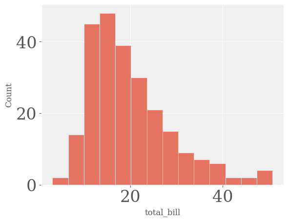

```python
# AFTER
plt.style.use(['ggplot','mycustomstyle'])
sns_plot()
```

If you're using Python, you should develop a custom theme, even by tweaking existing themes, as part of your class-work.

We would like to see this theme in all your visualizations.

```python
# RESET BACK TO DEFAULTS
plt.rcParams.update(plt.rcParamsDefault)
```

## Customize subplots/panels

Creating subplots is quite easy in matplotlib using the `subplots` function

You can add a title or other customization to just one of the panel

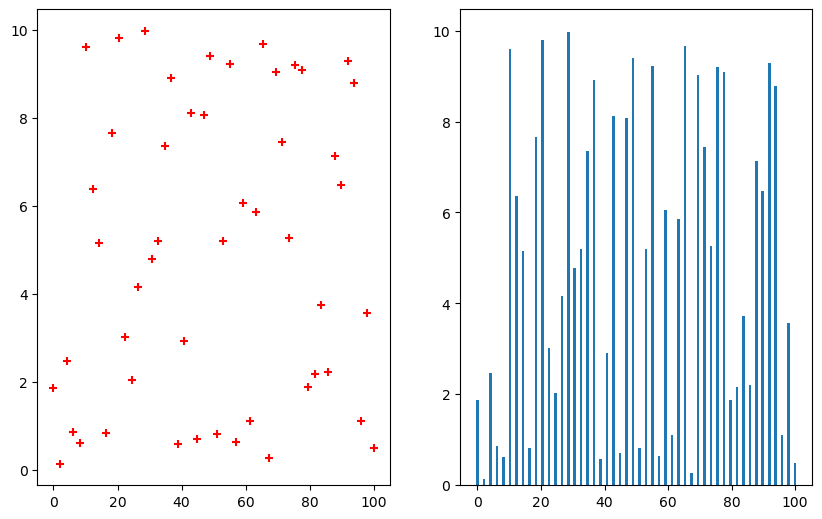

```python
x = np.linspace(0,100,50)
y = np.random.uniform(low=0, high=10, size=50)
fig, (ax1, ax2) = plt.subplots(1,2, figsize = (10,10/1.618))
ax1.scatter(x,y, c='red', marker='+')
ax2.bar(x,y);
plt.show()
```

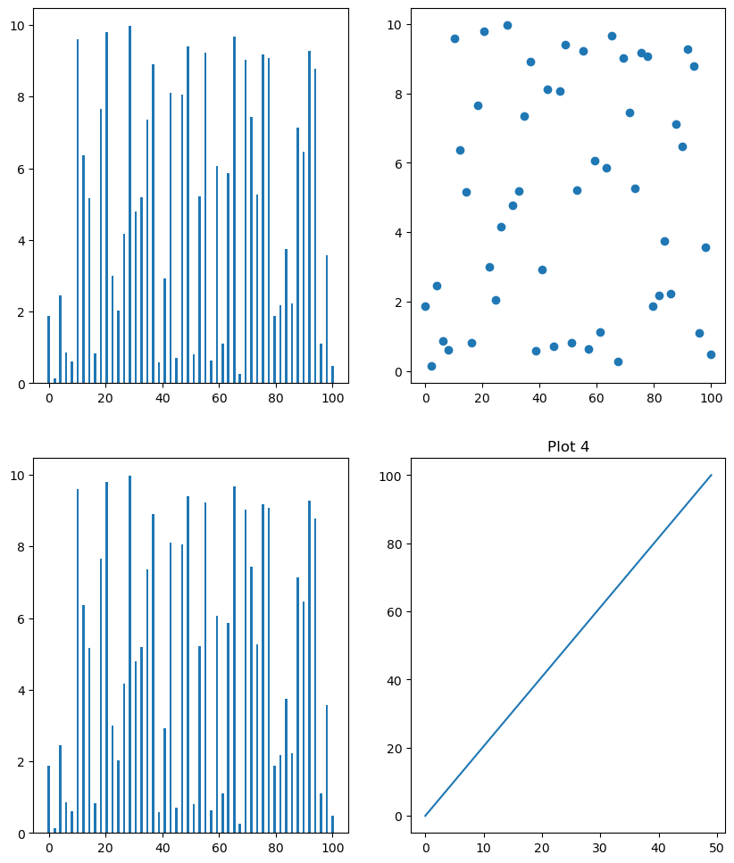

```python
fig, ax = plt.subplots(2,2, figsize = (10,12))
ax[0,0].bar(x,y)
ax[1,0].bar(x,y)
ax[0,1].scatter(x,y)
ax[1,1].plot(x)
ax[1,1].set_title('Plot 4')
plt.show()
```

You can also change the padding between the plots

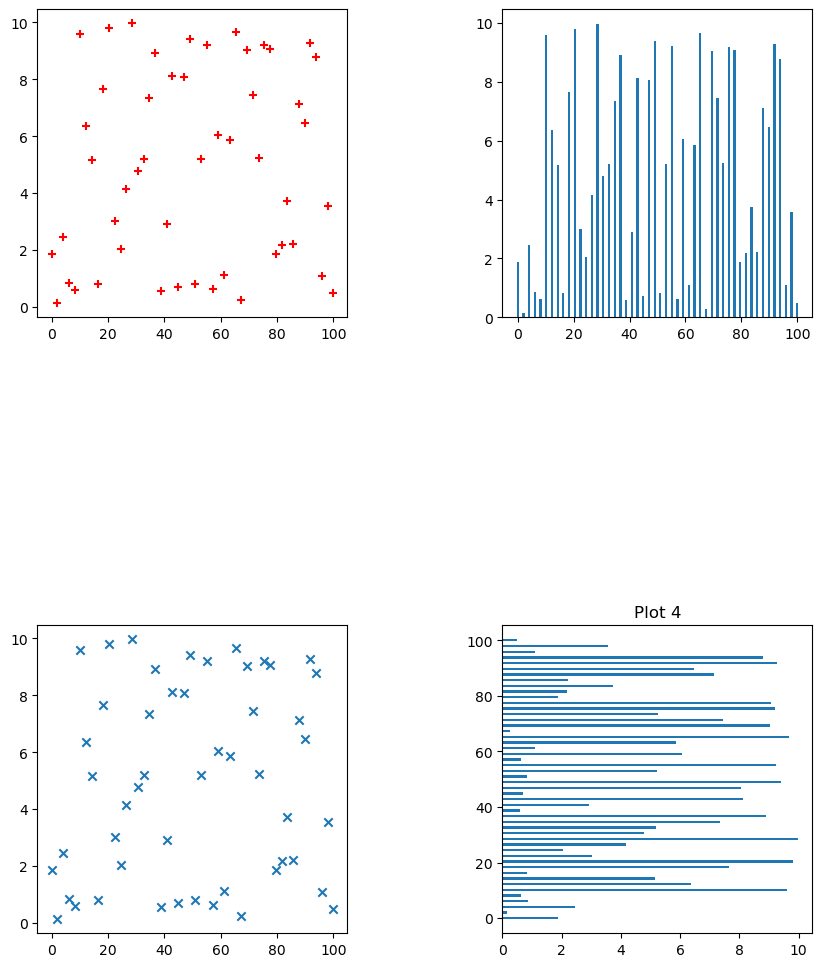

```python
fig, ((ax1,ax2),(ax3,ax4)) = plt.subplots(2,2, figsize=(10,12))
ax1.scatter(x,y,c='red', marker='+')
ax2.bar(x,y)
ax3.scatter(x,y, marker='x')
ax4.barh(x,y)
ax4.set_title('Plot 4')
plt.subplots_adjust(wspace=0.5, hspace=1.0)
plt.show()
```

## Axis alignment

It is often important for comparison purposes that the axes in a panel be on the same scale. This can be achieved by setting the `sharex` and `sharey` parameters in `subplots`, as needed

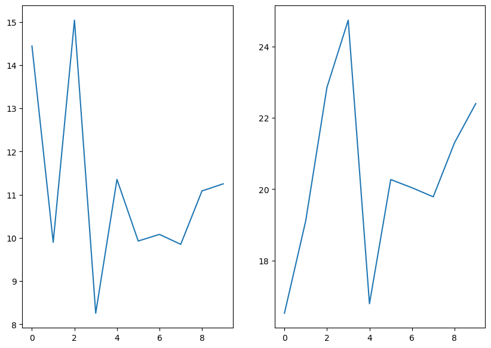

```python
x = np.linspace(0,100,50)
y1 = np.random.normal(loc = 10, scale=2, size=10)
y2 = np.random.normal(loc=20, scale=2, size=10)
fig, ((ax1,ax2)) = plt.subplots(1,2, figsize=(10,7))
ax1.plot(y1)
ax2.plot(y2);
plt.show()
```

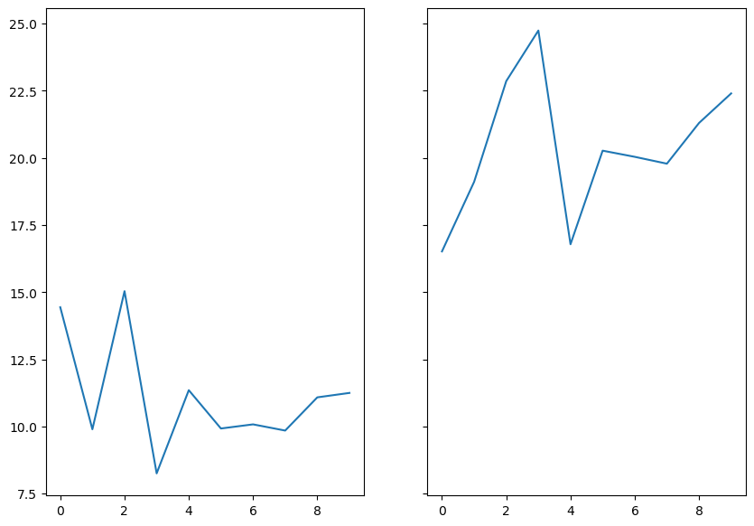

```python
fig, ((ax1,ax2)) = plt.subplots(1,2, figsize=(10,7), sharey=True)
ax1.plot(y1)
ax2.plot(y2);
plt.show()
```

## Size considerations

The size of a plot on your publication is often central to its aesthetics. This size can be specified in each matplotlib plot.

An aesthetically pleasing ratio of with to height is the *Golden Ratio*, which is approximately 1.618. We can write a function to ensure that for any particular width we desire, we can set the height to meet the Golden ratio.

```python
def set_size(width):
    """Set aesthetic figure dimensions following golden ratio
    Args:
        width (float): width of the figure in inches (what matplotlib uses)
    Returns:
        fig_dim (tuple): Dimensions of the figure in inches
    """
    golden_ratio = (5 ** 0.5 -1)/2
    fig_height = width * golden_ratio
    return width, fig_height
```

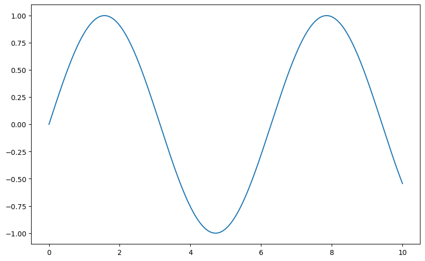

```python
x = np.linspace(0,10,num=1000)
fig, ax = plt.subplots(figsize = set_size(10))
ax.plot(x, np.sin(x))
plt.show()
```

# Lab Assignment

- Customize the following plot using the `lab-1.2.mplstyle` file

```python
print(plt.rcParams)
```

```
_internal.classic_mode: False
agg.path.chunksize: 0
animation.bitrate: -1
animation.codec: h264
animation.convert_args: ['-layers', 'OptimizePlus']
animation.convert_path: convert
animation.embed_limit: 20.0
animation.ffmpeg_args: []
animation.ffmpeg_path: ffmpeg
animation.frame_format: png
animation.html: none
animation.writer: ffmpeg
axes.autolimit_mode: data
axes.axisbelow: line
axes.edgecolor: black
axes.facecolor: white
axes.formatter.limits: [-5, 6]
axes.formatter.min_exponent: 0
axes.formatter.offset_threshold: 4
axes.formatter.use_locale: False
axes.formatter.use_mathtext: False
axes.formatter.useoffset: True
axes.grid: False
axes.grid.axis: both
axes.grid.which: major
axes.labelcolor: black
axes.labelpad: 4.0
axes.labelsize: medium
axes.labelweight: normal
axes.linewidth: 0.8
axes.prop_cycle: cycler('color', ['#1f77b4', '#ff7f0e', '#2ca02c', '#d62728', '#9467bd', '#8c564b', '#e377c2', '#7f7f7f', '#bcbd22', '#17becf'])
axes.spines.bottom: True
axes.spines.left: True
axes.spines.right: True
axes.spines.top: True
axes.titlecolor: auto
axes.titlelocation: center
axes.titlepad: 6.0
axes.titlesize: large
axes.titleweight: normal
```

[output cut: 253 more lines]

```
ytick.labelright: False
ytick.labelsize: medium
ytick.left: True
ytick.major.left: True
ytick.major.pad: 3.5
ytick.major.right: True
ytick.major.size: 3.5
ytick.major.width: 0.8
ytick.minor.left: True
ytick.minor.pad: 3.4
ytick.minor.right: True
ytick.minor.size: 2.0
ytick.minor.visible: False
ytick.minor.width: 0.6
ytick.right: False
```

```python
from pathlib import Path
cfgdir = ("./") # find your configuration folder
p = Path(cfgdir)
print(p)
```

```
.
```

```python
stylelib = (p / 'stylelib')
stylelib.mkdir(exist_ok=True)
```

```python
plt.style.library['seaborn-darkgrid']
```

```
RcParams({'axes.axisbelow': True,
          'axes.edgecolor': 'white',
          'axes.facecolor': '#EAEAF2',
          'axes.grid': True,
          'axes.labelcolor': '.15',
          'axes.linewidth': 0.0,
          'figure.facecolor': 'white',
          'font.family': ['sans-serif'],
          'font.sans-serif': ['Arial',
                              'Liberation Sans',
                              'DejaVu Sans',
                              'Bitstream Vera Sans',
                              'sans-serif'],
          'grid.color': 'white',
          'grid.linestyle': '-',
          'image.cmap': 'Greys',
          'legend.frameon': False,
          'legend.numpoints': 1,
          'legend.scatterpoints': 1,
          'lines.solid_capstyle': <CapStyle.round: 'round'>,
          'text.color': '.15',
          'xtick.color': '.15',
          'xtick.direction': 'out',
          'xtick.major.size': 0.0,
          'xtick.minor.size': 0.0,
          'ytick.color': '.15',
          'ytick.direction': 'out',
          'ytick.major.size': 0.0,
          'ytick.minor.size': 0.0})
```

```python
path = stylelib / 'lab-1.2.mplstyle' # create paths
path.write_text(''' # write into the file
axes.facecolor : F8F3F9
axes.grid : True
axes.linewidth : 2
font.family : sans-serif
font.size : 14
grid.linestyle : --
axes.prop_cycle: cycler(color=["#9355aa", "#6caa55"])
lines.linewidth : 5
lines.markersize : 14
xtick.labelsize : 14
ytick.labelsize : 14
''')
```

```
281
```

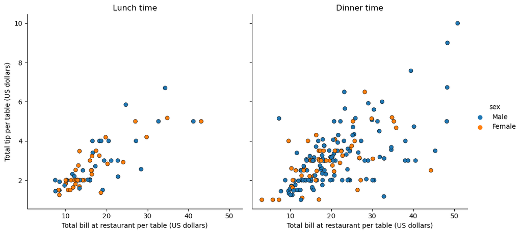

```python
# DO NOT MODIFY THIS FUNCTION: ONLY CHANGE lab-1.1.mplstyle FILE
# RESET BACK TO DEFAULTS
plt.rcParams.update(plt.rcParamsDefault)

def assignment_plot():
    g=sns.relplot(
    data=df,
    x="total_bill",
    y="tip",
    col="time",
    hue="sex", edgecolor='black'
    )
    #AXIS LABELS AND FONT SIZE
    g.axes[0,0].set_xlabel('Total bill at restaurant per table (US dollars)')
    g.axes[0,0].set_ylabel('Total tip per table (US dollars)')
    g.axes[0,1].set_xlabel('Total bill at restaurant per table (US dollars)')

    #TITLE FONT SIZE
    g.axes[0,0].set_title("Lunch time")
    g.axes[0,1].set_title("Dinner time")

    plt.show()

#DEFAULT PLOT
assignment_plot()
```

- Use the following to determine the color relevant codes: https://html-color-codes.info/colors-from-image/
- See here for a description of the meaning of the various rc-param entries
  - https://matplotlib.org/stable/tutorials/introductory/customizing.html

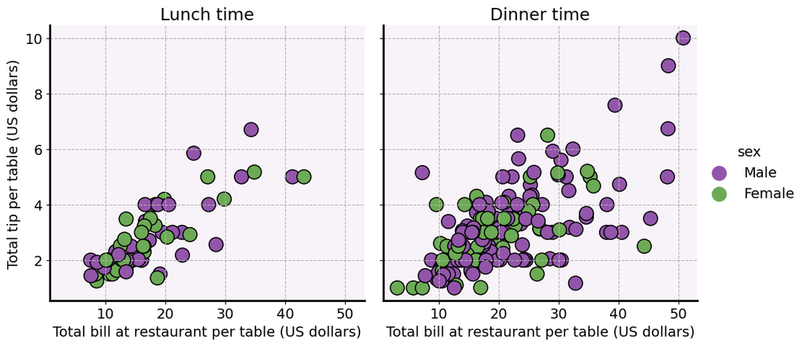

```python
# MODIFY "lab-1.2.mplstyle" AND RUN THE FOLLOWING CODE UNTIL IT REPRODUCES THE ORIGINAL PLOT
plt.style.use("./stylelib/lab-1.2.mplstyle")
assignment_plot()
```